# 685 Part 1

Matt Chesney & Casey Moroney

6/5/2022

## Introduction

This is a tutorial to walk through of how to complete Mixed regression in R. The tutorial is in two parts, the first is mixed regression utilizing linear methods and part 2 is generalized linear regression.

## Mixed models

What are mixed models? introduce fixed and random effects and how they differ.

In an experiment there is a unit that the experiment is being conducted on, this is the **experimental unit**. For the Experimental unit there is some measured attribute of interest, this is the **independent variable** or our Y.

A **fixed effect** is a treatment that is applied to our experimental unit. The treatment’s effect is ascertained by a shift in the average value of Y, or the independent variable being monitored.

The NULL hypothesis is that the treatment has no effect on the mean. $\beta$ is our Fixed effect

$$H_0: \beta=0$$
$$H_a: \beta \neq 0$$

Examples:  
1. Comparing tensile strengths of alloy blends.  
2. Comparing weight gain in pigs from several food types  
3. Comparing maximum speeds of cars with different fuel additives  
4. Comparing the blood pressure change in a patient over several days of medication

A **random effect** is also applied to the experimental unit. The treatment’s effect is determined by a difference in the variation in Y due to the application of the treatment. A random effect is assigned when the population of treatments is assumed to be homogeneous.

The NULL hypothesis is that the treatment has no effect on the variance. $\sigma_{R}$ is the variance attributed to our treatment.

$$H_0: \sigma_{R}=0$$
$$H_a: \sigma_{R}\neq 0$$
Examples:
1. A factory’s various production lines effect on variation tensile strength.
2. A pig farm’s pig pens’ effect on variation in weight gain
3. A professional driver’s effect on variation in top speeds of cars.
4. A medical subject’s effect on blood pressure medication treatment.

The mixed model contains both fixed effects and random effects.There are several ways this relationship can manifest. The fixed effect can have a consistent effect within the random effect, intercept changes but slope remains the same. The fixed effect random effect can only vary in the presence of the fixed effect, intercept constant and slope varies. The fixed effect can vary with respect to the random effect, slope and intercept change. Each of these options will be examined in our sleep data example.

Examples:  
1. Comparing tensile strengths of alloy blends from several production lines in a factory.  
2. Comparing weight gain in pigs from several food types living in one of several randomly assigned pens  
3. Comparing maximum speeds of cars with different fuel additives driven by randomly assigned professional drivers.  
4. Comparing the average blood pressure reduction after a treatment over several days applied to randomly selected subjects.

## Introduction to the Data

The sleepstudy dataset is available as part of the lme4 package. It is from a study conducted by Belenkyn et all (2003).

The response variable is the reaction time of the subjects to stimuli as recorded by researchers `Reaction`. The Subjects are the random effect, Subject. The number of days the subject underwent sleep deprivation is the fixed effect `Days`.

Below is the structure of the Sleep Study data

```r
str(sleepstudy)
```

```
## 'data.frame':    180 obs. of  3 variables:
##  $ Reaction: num  250 259 251 321 357 ...
##  $ Days    : num  0 1 2 3 4 5 6 7 8 9 ...
##  $ Subject : Factor w/ 18 levels "308","309","310",..: 1 1 1 1 1 1 1 1 1 1 ...
```

The first few lines of data. These are all observations for subject 308.

```r
head(sleepstudy)
```

```
##   Reaction Days Subject
## 1 249.5600    0     308
## 2 258.7047    1     308
## 3 250.8006    2     308
## 4 321.4398    3     308
## 5 356.8519    4     308
## 6 414.6901    5     308
```

Plot of Sleep Study data, color coded by patient numbers

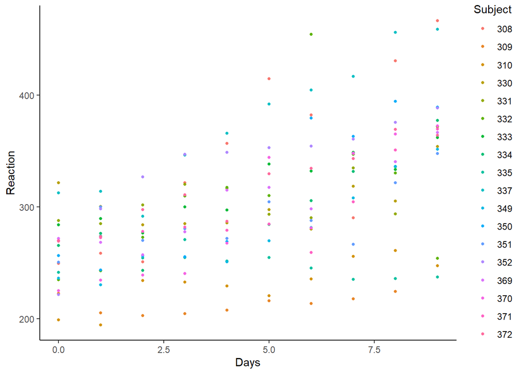

```r
ggplot(sleepstudy,aes(x=Days, y=Reaction, group=Subject, color=Subject)) +
    geom_point(size=1) + theme_classic()
```

## The Model

This example will follow the convention of using Greek symbols to denote fixed effects and capital letters to denote random effects.

The variables in out model are: $y$ is the reaction time of our subjects, $\beta_j$ is the Days coefficient  
$c_i$, our random intercept term.

Model 1, Only intercept varies [Fig 1]

$$y_{ij} = \alpha_{intercept} + c_{i} +
\beta_{j}*Days + e_{ij}$$

Model 2, intercept and slope vary and random terms are correlated: $\rho_{c_j,d_i} \ne 0$ [Fig 2] Here $d_i$ is our random slope term.

$$y_{ij} = \alpha_{intercept} + c_{i} +
(\beta_{j}+d_{i})*Days + e_{ij}$$
Model 3, intercept and slope vary and random terms are not correlated: $\rho_{c_j,d_i} = 0$ [Fig 3]

$$y_{ij} = \alpha_{intercept} + c_{i} +
(\beta_{j}+d_{i})*Days + e_{ij}$$

## LME4 Package

To analyze the mixed effect model we will utilize the R package LME4. The relevant syntax for the model is as follows:

| Model Type | Syntax | Abbreviated Syntax |  |
| --- | --- | --- | --- |
| Random intercept | `(1\|RandomEffect)` |  |  |
| Random Slope effect | `(0+FixedEffect\|RandomEffect)` |  |  |
| Random intercept and slope with random effect correlated | `1+FixedEffect+(1+FixedEffect\|RandomEffect)` | `FixedEffect+(FixedEffect\|RandomEffect` |  |
| Random intercept and slope with random effect uncorrelated | `1+FixedEffect+(1\|RandomEffect)+(0+FixedEffect\|RandomEffect)` | `FixedEffect+(FixedEffect\|\|RandomEffect)` |  |

We will utilize the abbreviated syntax where appropriate.

### REML

Restricted Maximum likelihood is recommended for the final model, however REML does not work with model selection techniques such as AIC and BIC. If it is necessary to compare models REML should not be used. Once the best model is selected REML can be used with that model for more accurate confidence intervals.This can be achieved in the LME4 package by adding `REML=False` as an option. The default in LME4 is true.

For model comparison we will use the option `REML=F`, once the model is selected we will use REML

### Model 1 (Fig 1)

```r
model1 <- lmer(Reaction ~ Days + (1|Subject), sleepstudy,REML=F)
summary(model1)
```

```
## Linear mixed model fit by maximum likelihood  ['lmerMod']
## Formula: Reaction ~ Days + (1 | Subject)
##    Data: sleepstudy
##
##      AIC      BIC   logLik deviance df.resid
##   1802.1   1814.9   -897.0   1794.1      176
##
## Scaled residuals:
##     Min      1Q  Median      3Q     Max
## -3.2347 -0.5544  0.0155  0.5257  4.2648
##
## Random effects:
##  Groups   Name        Variance Std.Dev.
##  Subject  (Intercept) 1296.9   36.01
##  Residual              954.5   30.90
## Number of obs: 180, groups:  Subject, 18
##
## Fixed effects:
##             Estimate Std. Error t value
## (Intercept) 251.4051     9.5062   26.45
## Days         10.4673     0.8017   13.06
##
## Correlation of Fixed Effects:
##      (Intr)
## Days -0.380
```

#### Output

The summary of the model gives us AIC, BIC, and log likelihood scores along with deviance and degrees of freedom. After the scaled residuals we get parameter estimates. listed first are estimates for the random effects. The $c_i$ standard deviation is estimated at 36.01 and the $e_{ij}$ is estimated at 30.9. Next are the estimates for the fixed effects of intercept and the `Days` term.

### Visulization of model 1

The lines in this graph are the model for each of the `Subjects`.
$$y_{ij} =
\alpha_{intercept} + c_{i} + \beta_{j}*Days$$

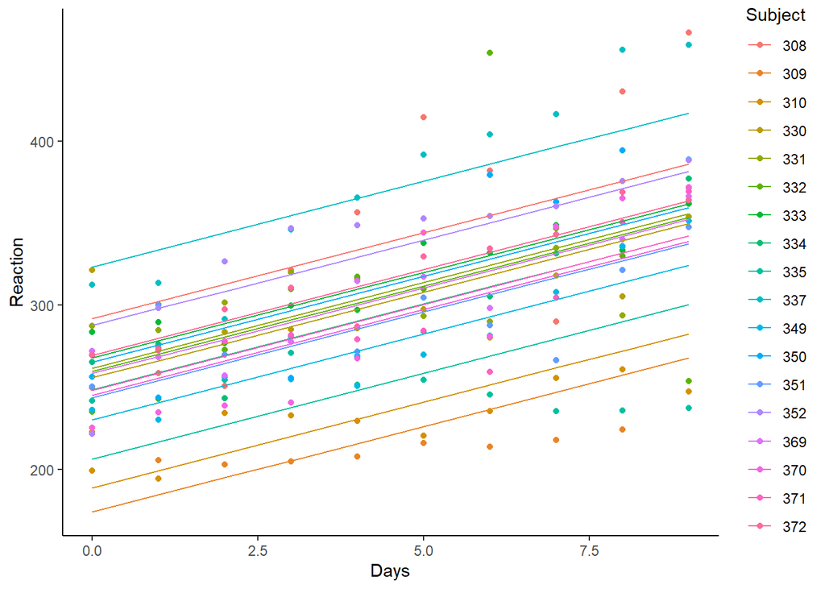

```r
ggplot(NULL) +
    geom_point(data=sleepstudy,aes(x=Days, y=Reaction, group=Subject, color=Subject))+geom_line(data=sleepstudy%>%mutate(pred_dist=fitted(model1)),aes(x=Days, y=pred_dist, group=Subject, color=Subject))+ theme_classic()
```

## Model 2 [Fig 2]

```r
model2 <- lmer(Reaction ~ Days + (Days|Subject), sleepstudy,REML=F)
summary(model2)
```

```
## Linear mixed model fit by maximum likelihood  ['lmerMod']
## Formula: Reaction ~ Days + (Days | Subject)
##    Data: sleepstudy
##
##      AIC      BIC   logLik deviance df.resid
##   1763.9   1783.1   -876.0   1751.9      174
##
## Scaled residuals:
##     Min      1Q  Median      3Q     Max
## -3.9416 -0.4656  0.0289  0.4636  5.1793
##
## Random effects:
##  Groups   Name        Variance Std.Dev. Corr
##  Subject  (Intercept) 565.48   23.780
##           Days         32.68    5.717   0.08
##  Residual             654.95   25.592
## Number of obs: 180, groups:  Subject, 18
##
## Fixed effects:
##             Estimate Std. Error t value
## (Intercept)  251.405      6.632  37.907
## Days          10.467      1.502   6.968
##
## Correlation of Fixed Effects:
##      (Intr)
## Days -0.138
```

### Output

In addition to the output received in model 1, we also get an estimate for the $d_i$ term in the random effects listed in the `Days` row. We also get the $\rho$ estimate for $(c_i , d_i)$ which is .08.

### Visualization of model 2

The lines on this plot represent each of the subjects with the correlation term following the equation:
$$y_{ij} = \alpha_{intercept} + c_{i} +
(\beta_{j}+d_{i})*Days$$

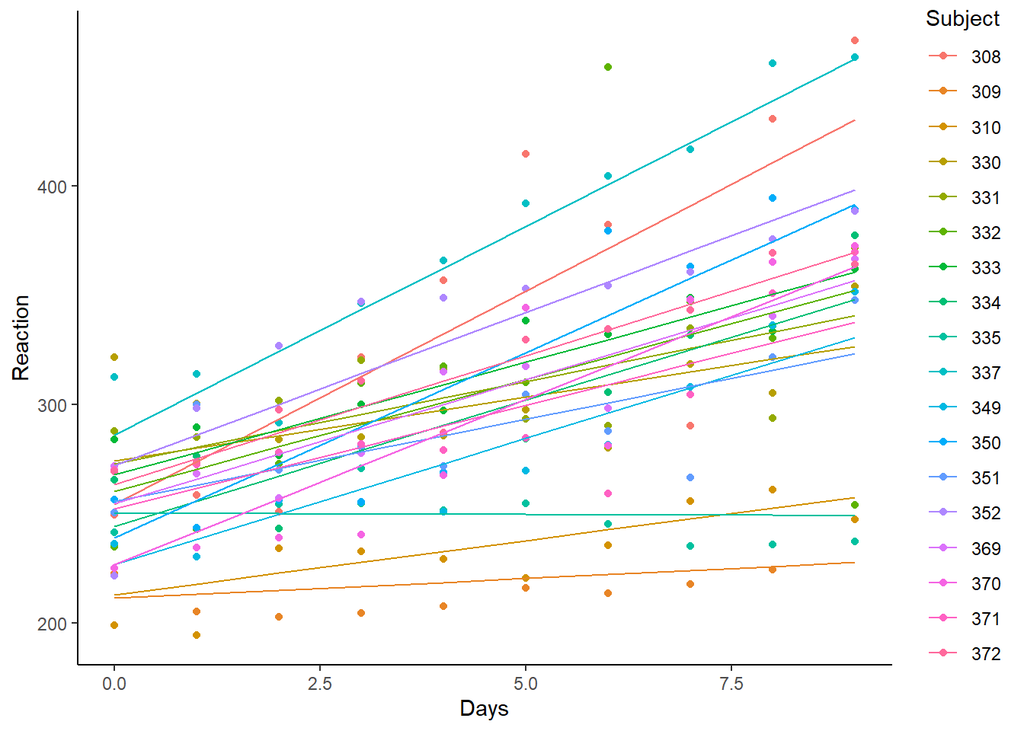

```r
ggplot(NULL) +
    geom_point(data=sleepstudy,aes(x=Days, y=Reaction, group=Subject, color=Subject))+geom_line(data=sleepstudy%>%mutate(pred_dist=fitted(model2)),aes(x=Days, y=pred_dist, group=Subject, color=Subject))+ theme_classic()
```

### Model 3 [Fig 3]

```r
model3 <- lmer(Reaction ~ Days + (Days||Subject), sleepstudy,REML=F)
summary(model3)
```

```
## Linear mixed model fit by maximum likelihood  ['lmerMod']
## Formula: Reaction ~ Days + ((1 | Subject) + (0 + Days | Subject))
##    Data: sleepstudy
##
##      AIC      BIC   logLik deviance df.resid
##     1762     1778     -876     1752      175
##
## Scaled residuals:
##     Min      1Q  Median      3Q     Max
## -3.9535 -0.4673  0.0239  0.4625  5.1883
##
## Random effects:
##  Groups    Name        Variance Std.Dev.
##  Subject   (Intercept) 584.27   24.172
##  Subject.1 Days         33.63    5.799
##  Residual              653.12   25.556
## Number of obs: 180, groups:  Subject, 18
##
## Fixed effects:
##             Estimate Std. Error t value
## (Intercept)  251.405      6.708   37.48
## Days          10.467      1.519    6.89
##
## Correlation of Fixed Effects:
##      (Intr)
## Days -0.194
```

### Output

The output for model 3 is in the same format as model 2 but without the correlation term.

### Data visulization for model 3

Each line represents the subject without a random effects correlation term according to the equation:
$$y_{ij} =
\alpha_{intercept} + c_{i} + (\beta_{j}+d_{i})*Days$$

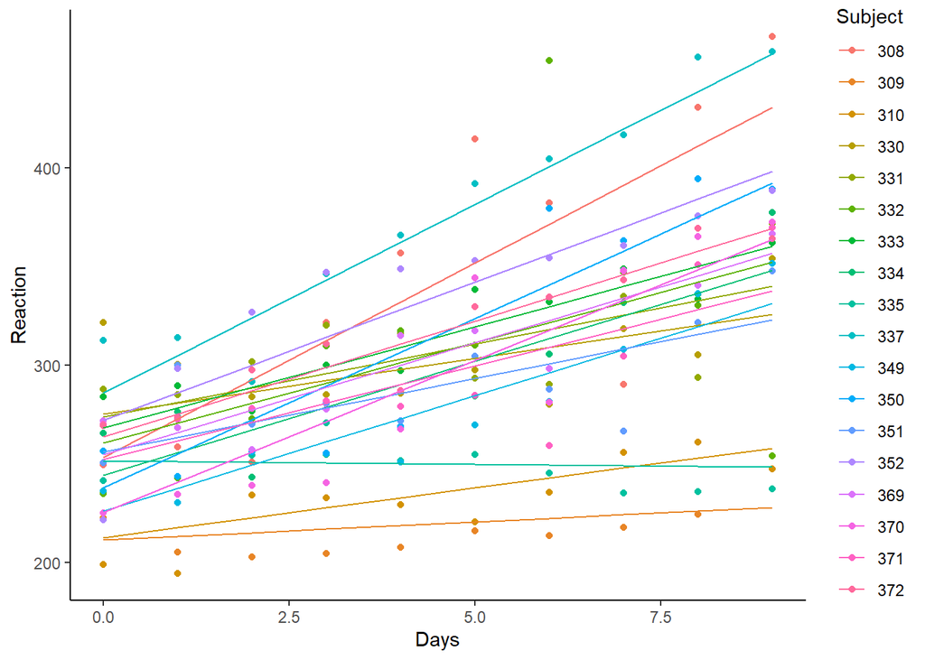

```r
ggplot(NULL) +
    geom_point(data=sleepstudy,aes(x=Days, y=Reaction, group=Subject, color=Subject))+geom_line(data=sleepstudy%>%mutate(pred_dist=fitted(model3)),aes(x=Days, y=pred_dist, group=Subject, color=Subject))+ theme_classic()
```

Here we compare the AIC, BIC, and log likelihood scores for each of the models.

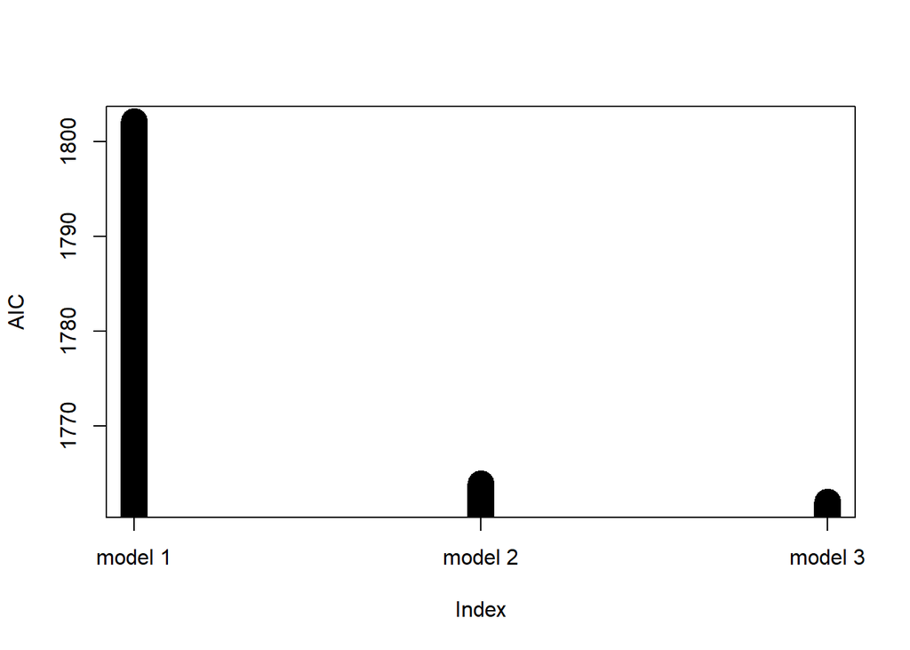

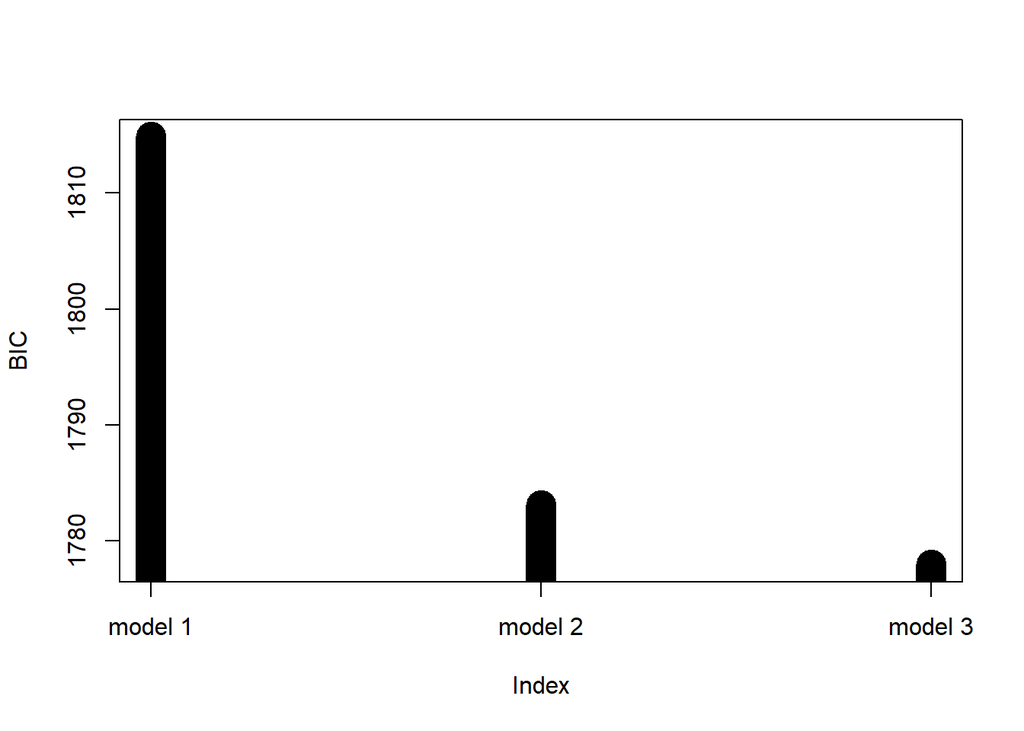

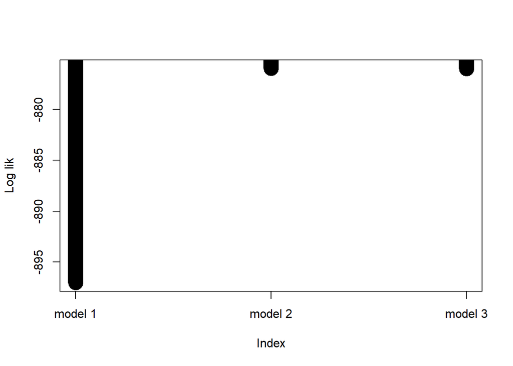

```
## Data: sleepstudy
## Models:
## model1: Reaction ~ Days + (1 | Subject)
## model3: Reaction ~ Days + ((1 | Subject) + (0 + Days | Subject))
## model2: Reaction ~ Days + (Days | Subject)
##        npar    AIC    BIC  logLik deviance   Chisq Df Pr(>Chisq)
## model1    4 1802.1 1814.8 -897.04   1794.1
## model3    5 1762.0 1778.0 -876.00   1752.0 42.0754  1  8.782e-11 ***
## model2    6 1763.9 1783.1 -875.97   1751.9  0.0639  1     0.8004
## ---
## Signif. codes:  0 '***' 0.001 '**' 0.01 '*' 0.05 '.' 0.1 ' ' 1
```

AIC and BIC select the uncorrelated model ( model 3), log likelihood selects the correlated model (model 2) . We will go with model 3.

## Confidence intervals for mixed parameters

### Refit with REML

First, as mentioned previously we will refit the selected model with `REML=T`.

```r
model3 <- lmer(Reaction ~ Days + (Days||Subject), sleepstudy,REML=T)
```

### Confidence intervals in LME4

The lme4 package contains a `confint.mermod()` function that computes confidence intervals for fixed and random effects. The function is shown below with all of its parameters.

```r
# S3 method for merMod credit: https://www.rdocumentation.org/packages/lme4/versions/1.1-29/topics/confint.merMod
confint(object, parm, level = 0.95,
    method = c("profile", "Wald", "boot"), zeta,
    nsim = 500,
        boot.type = c("perc","basic","norm"),
        FUN = NULL, quiet = FALSE,
    oldNames = TRUE, ...)
```

By default all parameters will be output at a 95% interval utilizing the profile likelihood method. Below we show the confidence intervals for our selected model. The parameters are output in the same order as model summary. sig01 is the $c_i$ term, sig02 is the $d_j$ term, sigma is the $e_{ij}$ term. fixed effect terms are listed by name.

```r
confint.merMod(model3)
```

```
## Computing profile confidence intervals ...
```

```
##                  2.5 %     97.5 %
## .sig01       15.258647  37.786471
## .sig02        3.964074   8.769159
## .sigma       22.880555  28.787598
## (Intercept) 237.572148 265.238062
## Days          7.334067  13.600505
```

### Bootstrap Confidence intervals

Next we use the same function to calculate the bootstrap confidence intervals for all parameters. The default number of iterations is 500.

```r
confint.merMod(model3, method = 'boot')
```

```
## Computing bootstrap confidence intervals ...
```

```
##
## 1 warning(s): Model failed to converge with max|grad| = 0.0020736 (tol = 0.002, component 1)
```

```
##                  2.5 %     97.5 %
## .sig01       12.676086  35.540620
## .sig02        3.489138   8.302889
## .sigma       22.616364  28.207600
## (Intercept) 237.778388 263.855464
## Days          7.688879  13.430344
```

### Extracting Design matrix

The design matrix for model 3:
$$y= X
\beta+Zu+e$$

Eache element can be extracted as seen below:

```r
Xi=getME(model3,"X")
Zi=getME(model3,"Z")
Ui=getME(model3,"u")
beta=getME(model3,"beta")
```

# Bayesian Methods

Bayesian methods are another option to approach mixed effects problems. Bayesian methods are especially helpful with smaller sample sizes, but are great for large samples as well. We will be using the *brms* package, which uses syntax similar to the *lme4* package.

## Bayes Theorem

In Bayesian statistics the modelling approach is based off of Bayes’ theorem, where we use information in the observed data to update knowledge about the model parameters. The background information is known as the prior distribution and combined with likelihood functions to determine the posterior distribution.

$$P(\theta,
y)=P(\theta)P(y|\theta)$$
Where the posterior distribution is represented by:
$$P(\theta, y)$$

The prior distribution:
$$P(\theta)$$
and the sampling distribution represented by:
$$P(y|\theta)$$
Given this information, we can use our data (sampling distribution) along with a prior to calculate the posterior.

## Linear Mixed Models

### Introduction to the dataset

We will be using a dataset that comes with the *lme4* pacakge called “sleepstudy”. This dataset comes from a study conducted by Belenkyn et al (2003).

In this dataset, we have 18 subjects with varying degrees of sleep deprivation.

```r
str(lme4::sleepstudy)
```

```
## 'data.frame':    180 obs. of  3 variables:
##  $ Reaction: num  250 259 251 321 357 ...
##  $ Days    : num  0 1 2 3 4 5 6 7 8 9 ...
##  $ Subject : Factor w/ 18 levels "308","309","310",..: 1 1 1 1 1 1 1 1 1 1 ...
```

The response variable, `Reaction`, represents the average reaction time in milliseconds observed for subjects in a sleep deprivation study. `Days` represents the number of days the given `Subject` was deprived of sleep.

```r
head(lme4::sleepstudy)
```

```
##   Reaction Days Subject
## 1 249.5600    0     308
## 2 258.7047    1     308
## 3 250.8006    2     308
## 4 321.4398    3     308
## 5 356.8519    4     308
## 6 414.6901    5     308
```

Below we have a simple plot of the dataset.

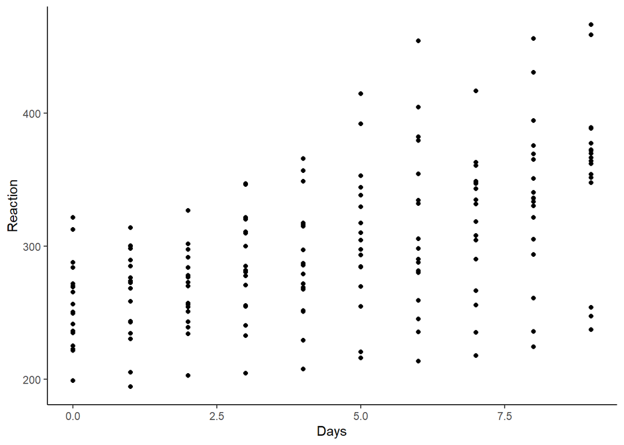

```r
lme4::sleepstudy %>%
    ggplot(aes(x = Days, y = Reaction)) + geom_point() + theme_classic()
```

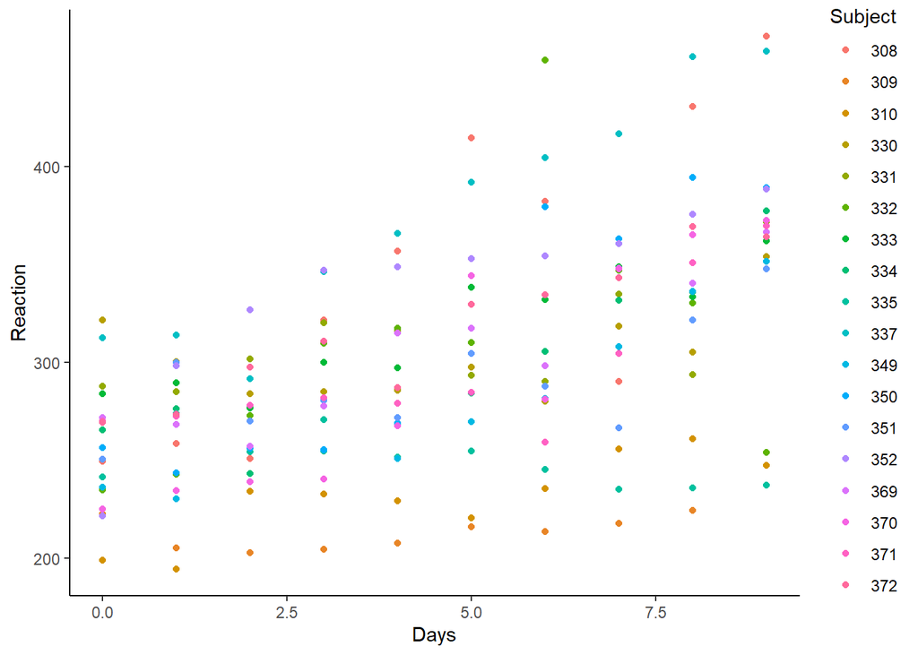

```r
lme4::sleepstudy %>%
    ggplot(aes(x = Days, y = Reaction, color = Subject)) + geom_point() + theme_classic()
```

### Model 1

Our first model assumes that the slope (reaction time over number of days) is the same for each subject. In this case, the goal is to estimate the intercept, which represents the baseline reaction time without sleep deprivation, for each subject.

$$y_{ij} = \beta_0 + \beta_{1}t_j + C_{i}
+ e_{ij}$$
where $y_{ij}$ is the reaction time of the $i^{th}$ subject at j days, $\beta_0$ is the population intercept, $\beta_1$ is the population slope, $t_j$ is the number of days at time $t$, $C_i$ is the random intercept for subject $i$, and $e_{ij}$ is the error term. Since the time markers are in days that are equally spread apart, ${t_j}$ is simply ${j}$, number of days.

Assumptions for this model:  
1. $e_{ij}$’s are independent with mean equal to 0, finite variance, and follow $Normal(0,\sigma^2_e )$  
2. $C_1, C_2, ..., C_n$ are all independent and follow $Normal(0,\sigma^2_c)$  
3. $e_{ij}$ and $C_i$ are independent  
4. $e_{ij}$, $C_i$, and $t_j$ are all independent

where,
$$i \in \{1,...,18\} , and$$
$$j \in \{0,...,9\}$$

#### Priors

We need to choose prior distributions for parameters that might be helpful in forming a posterior distribution. I will use fitted parameters from a mixed linear model on the same data built using the `lme4` package. See the `lme4` section of this manual for more info.

First, load in the *rstan* and *brms* packages, then build our base model.

```r
require(rstan)
require(brms)

# Fit a base model using lmer
lmm <- lmer(Reaction ~ Days + (1|Subject), sleepstudy)

# Pull base model estimates from lmer model
b0 <- summary(lmm)$coefficients[1,1]
b1 <- summary(lmm)$coefficients[1,2]
se <- summary(lmm)$sigma
te <- attr(summary(lmm)$varcor$Subject, "stddev")
```

The priors we are using:
$$\beta_0 \sim
N(251, 10)$$
$$\beta_1 \sim N(10,
10)$$
$$\sigma_e \sim N(0,
31)$$
$$\tau_0 \sim N(0, 37)$$
***

#### BRMS package

##### Sampler

As mentioned before, this package does not fit models itself but uses `Stan` on the back end. Stan is a probabilistic programming language with a C++ backend. By default this backend uses the static Hamiltonian Monte-Carlo (HMC) Sampler and its extension the No-U-Turn Sampler (NUTS) by Hoffman and Gelman(2014).

Alternatives to these algorithms, not available in the `brms` package include random-walk Metropolis and variations, Gibbs-sampling, and slice-sampling. The documentation for this package concludes that its choice of samplers converge much more quickly especially for high-dimensional models regardless of whether the priors are conjugate or not. Read the `brms` documentation overview for more information.

##### The brm() function

This function in the `brms` package fits generalized linear/non-linear multivariate multilevel models (MMM). To set priors, we use the `prior()` function, which accepts a distribution with parameters as well as a `class` argument which designates which parameter the prior is associated with. The `brm` function does not handle parameters set as variables inside of `prior()` well, so you will need to manually enter the prior values into the `prior()` function.

##### Default arguments for brm()

**Chains**: The number of Markov chains to use. The advantage of using more chains is that we can be more confident of our understanding of the posterior distribution as each chain has a different starting point. If running in parallel using the “cluster” option, this package limits the number of chains to the number of cores the system has. Defaults to 4.

**Iter**: The total number of iterations per chain. Some datasets may require more iterations to converge - meaning it takes longer to reach a point where further iterations do not improve the model. A higher number will cause the model to take longer to fit, see a comparison below. Defaults to 2,000.

**Warmup**: Also known as burn-in. This refers to the number of iterations at the beginning of an MCMC run to be thrown away. The warm-up period is a hyper-parameter that is meant to give the Markov Chain time to reach its equilibrium distribution. The idea here is that a “bad” randomized starting point may over-sample regions that aren’t representative of the equilibrium distribution. Defaults to `floor(iter/2)`.

**Thin**: Thinning consists of picking values at each k-th step and removing them from the Markov chain. This helps speed up model convergence if number of iterations, `iter`, is large. Defaults to 1, meaning all values are kept. Choose a value > 1 to save memory and computation time if `iter` is large.

**Cores**: Number of CPU cores to utilize for building chans. As chains can be created independent of one another, parallelization can be utilized to speed up the process. You can see how many cores are available on your machine by using the `detectCores()` function from the package `parallel`.

**Family**: Defaults to Gaussian. Since we are building a *linear* mixed model, we will use leave use the default. More info on specifying distribution family can be found in the generalized mixed model section of this manual.

```r
priors <- c(prior(normal(251, 10), class = Intercept), # intercept prior
            prior(normal(10, 10), class = b), # slope prior
            prior(normal(0, 31), class = sigma), # population sd
            prior(normal(0, 37), class = sd) # tau0, group sd
            )

model1 <- brm(Reaction ~ Days + (1 | Subject),
             data = sleepstudy,
             prior = priors,
             chains = 4,
             iter = 10000,
             # warmup = ,
             thin = 1,
             cores = 4,
             family = gaussian()
             )

summary(model1)
```

**Notes**: * Within `prior()` calls, sigma refers to the population-level and sd refers to the group-level * The `brms` package adjustes prior distributions to be greater than 0 in `sd` and `sigma` priors. * To compare these results with the output from a model built with the `lme4` package, please see the frequentist section of this manual above. * More iterations take longer to fit. If a model fails to converge, you will see a warning output and may need to adjust iterations or other fitting options in order to be successful. Experiment with iterations until you reach an acceptable output. * If you want to compare fitting times for different iterations, refer to the “iteration_comparison” section of accompanying code this markdown file.

#### Model Summary

With our model built, we can now get estimates of the parameters. R’s built-in `summary()` function does a good job explaining each portion of the output one item at a time.

```r
summary(model1)
```

```
##  Family: gaussian
##   Links: mu = identity; sigma = identity
## Formula: Reaction ~ Days + (1 | Subject)
##    Data: sleepstudy (Number of observations: 180)
##   Draws: 4 chains, each with iter = 10000; warmup = 5000; thin = 1;
##          total post-warmup draws = 20000
##
## Group-Level Effects:
## ~Subject (Number of levels: 18)
##               Estimate Est.Error l-95% CI u-95% CI Rhat Bulk_ESS Tail_ESS
## sd(Intercept)    45.50      8.98    30.89    65.98 1.00     3243     6346
##
## Population-Level Effects:
##           Estimate Est.Error l-95% CI u-95% CI Rhat Bulk_ESS Tail_ESS
## Intercept   225.82      9.19   207.06   243.14 1.00     4271     7664
## Days         10.46      0.81     8.85    12.06 1.00    19788    15017
##
## Family Specific Parameters:
##       Estimate Est.Error l-95% CI u-95% CI Rhat Bulk_ESS Tail_ESS
## sigma    31.16      1.73    28.01    34.79 1.00    18187    15167
##
## Draws were sampled using sampling(NUTS). For each parameter, Bulk_ESS
## and Tail_ESS are effective sample size measures, and Rhat is the potential
## scale reduction factor on split chains (at convergence, Rhat = 1).
```

The first 5 lines of the summary output describe our model and model inputs defined in the `brm` call.

##### Group-Level Effects

If you want to access a specific estimate from the model object, they can be accessed by using the `$` operator on the summary object of the model. For example: `summary(model1)$random$Subject` returns Subject-specific (or group level) random effects:

```
##               Estimate Est.Error l-95% CI u-95% CI     Rhat Bulk_ESS Tail_ESS
## sd(Intercept) 45.49705  8.976692 30.89393  65.9807 1.000462 3242.774  6345.52
```

If you want to access individual parts of this output, the `$` notation can be used in addition to the last command to access each part.

Our estimate for the subject-specific random effect is 45.5, which differs from the base model estimate $\tau_0$ = 37 although the base model estimate is still within the Bayesian credible interval **(30.8939279, 65.9806965)**.

**Rhat** ($\hat R$) for a given parameter estimate is a measure of whether the samples obtained are likely representative of the true distribution. Put simply, it is the square root of the estimated total variance over within-chain variance. It’s formula:

$$\hat R=\sqrt{\frac{\hat {var}^+
(\theta|y)} {W}}$$

where,

- Total posterior variance of a given paramater, ${\hat {var}}^+(\theta |y)$ = $\frac{N-1}{N}W + \frac{1}{N}B$
- The within-chain variance estimate $W=\frac{1}{M} \sum_{m=1}^M s_m^2$, where $s^2_m=\frac{1}{N-1}\sum_{n=1}^N (\theta^{(n,m)}-\bar \theta^{(\cdot, m)})^2$
- Between-chain variance estimate $B=\frac{N}{M-1}\sum_{m=1}^M(\bar\theta^{(\cdot,m)}-\bar\theta^{(\cdot,\cdot)})^2$, where $\bar\theta^{(\cdot,m)}=\frac{1}{N}\sum_{n=1}^N\theta^{(n,m)}$, $\bar\theta^{(..)}=\frac{1}{M}\sum_{m=1}^M\bar\theta^{(.m)}$
- $N$ is the total number of iterations (iters) per chain, $M$ is total number of chains, $S=MN$ is the total number of draws from all chains, $\theta^{(nm)}$ is the $n$th draw of the $m$th chain, $\theta^{(.m)}$ is the average of draws from the $m$th chain, and $\theta^{(..)}$ is the parameter of interest.

The STAN backend code uses split $\hat R$ that takes $M$ chains, splits them in half, then performs the $\hat R$ calculation on the resulting $2M$ chains. So if there is only one chain, $\hat R$ can still be calculated ($M=2$).

If this value is larger than 1.1, it is an indication that the model has not converged adequately. This can be accessed for each parameter estimate within the model summary. For example, $\hat R$ for subject specific random intercept, $\hat R_{\hat\sigma_\tau}$ is accessed with `summary(model1)$random$Subject$Rhat` = 1.0004619.

**Bulk_ESS** or bulk effective sample size is a diagnostic for the sampling efficiency in the bulk of the posterior distribution. It measures the information content of a sample chain. It can be thought of as the minimum sample size from the posterior which has the same efficiency in estimating the posterior as a chain of MCMC samples. A higher number here is better - ESS > 400 is recommended (Vehtari, et al).

$$ESS = NM /\hat\pi$$
where $N$ is the length of the chain, $M$ is the total number of chains, and $\hat\pi$ represents estimated correlation between lagged samples in the chain.

**Tail_ESS** represents the minimum sample size needed to create 5% and 95% quantiles of the posterior.

$\hat R$ of 1 and $ESS$ greater than 400 are required to ensure an MCMC sample is useful in practice. More information on $\hat R$, $ESS$, and $Tail ESS$ calculations - Vehtari, et al (2021).

##### Population-Level Effects

This section shows our intercept estimate, $\hat\beta_0$ = 225.82, our slope estimate, $\hat\beta$ = 10.46 along with credible intervals, $\hat R$, and bulk/tail ESS for each.

##### Family Specific Parameters:

This shows our estimate for $\hat\sigma_e$ = 31.16, compared to our estimate from the `lme4` model 30.99.

#### Posterior Summary

While the `summary()` function has a tidy appearance, the `posterior_summary()` function produces much more information about the estimates.

```r
posterior_summary(model1)
```

```
##                             Estimate  Est.Error        Q2.5       Q97.5
## b_Intercept               225.815031  9.1911417  207.059254  243.139418
## b_Days                     10.460370  0.8143317    8.849644   12.059554
## sd_Subject__Intercept      45.497052  8.9766917   30.893928   65.980696
## sigma                      31.157295  1.7308522   28.011643   34.785292
## r_Subject[308,Intercept]   65.857783 12.8854014   41.325501   91.618211
## r_Subject[309,Intercept]  -54.698316 12.3446155  -78.406254  -30.424188
## r_Subject[310,Intercept]  -39.718746 12.2620888  -63.369443  -15.158436
## r_Subject[330,Intercept]   28.880235 12.8131278    4.369458   54.640406
## r_Subject[331,Intercept]   34.793345 12.8059574   10.392432   60.383638
## r_Subject[332,Intercept]   32.736641 12.6156329    8.509095   58.156346
## r_Subject[333,Intercept]   41.239982 12.7365647   16.751509   66.592082
## r_Subject[334,Intercept]   21.426907 12.5674647   -2.898328   46.335969
## r_Subject[335,Intercept]  -21.683041 12.4133523  -45.545215    2.979225
## r_Subject[337,Intercept]   97.790901 13.2934022   72.045141  124.163059
## r_Subject[349,Intercept]    2.884475 12.5980863  -21.166225   28.551021
## r_Subject[350,Intercept]   38.729063 12.7983818   14.094367   64.545339
## r_Subject[351,Intercept]   16.467353 12.6653007   -7.898182   41.714075
## r_Subject[352,Intercept]   61.421339 12.9741721   36.485774   87.592525
## r_Subject[369,Intercept]   31.599951 12.7724486    7.229659   57.069432
## r_Subject[370,Intercept]   17.938502 12.7057680   -6.295288   43.517534
## r_Subject[371,Intercept]   21.116345 12.5883130   -3.057218   46.294665
## r_Subject[372,Intercept]   42.851785 12.8433562   18.186528   68.495246
## lprior                    -17.990297  1.7462737  -22.064231  -15.560205
## lp__                     -910.667192  4.7351458 -920.872460 -902.494991
```

`lprior` and `lp__` are used for automatic prior/likelihood sensitivity analysis using an additional package, `priorsens` and are not included in the `brms` documentation.

#### Plots

If you want to show trace and density plots for all model parameters, use `plot(model)`:

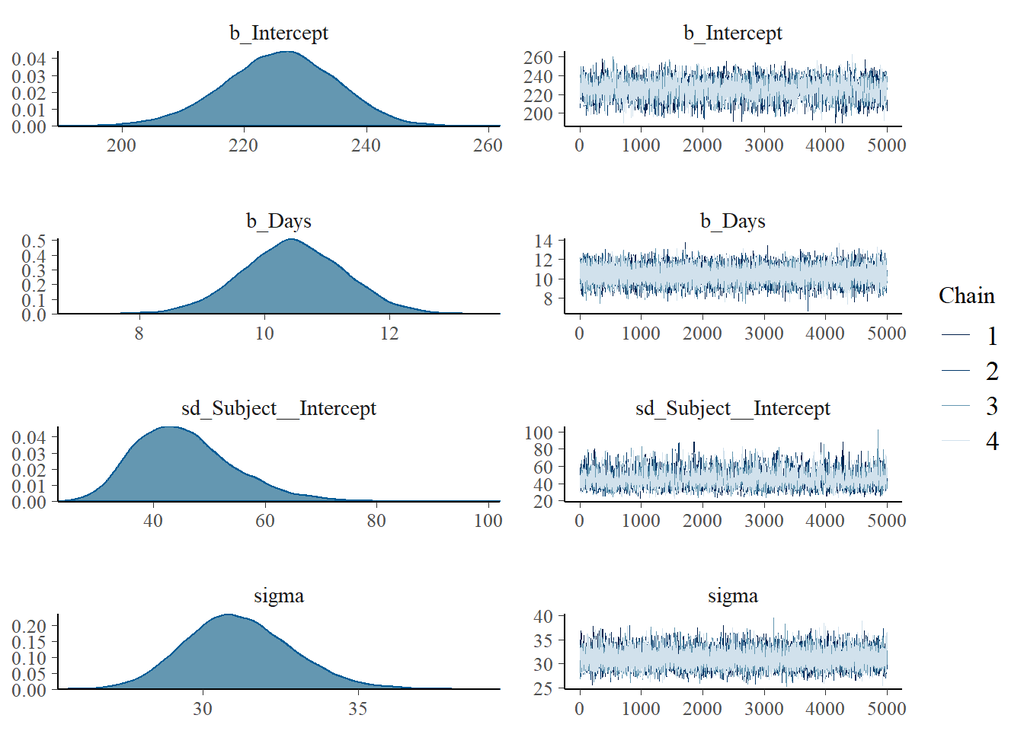

```r
plot(model1)
```

The left side of the plot shows the overall density of our parameter estimates. The right side of the plot output shows a trace plot with parameter estimates across all iterations. You can also plot individual parameters by adding the `pars=` argument to the plot function call. `plot(model1, pars=b_Intercept)` for example only outputs the top two plots from the output above.

#### Plotting Model Estimates

As an alternative the using the `summary(model)$` notation, it’s also possible to pull model coefficients and error estimates using the `coef()` function. We can access intercept estimates for each Subject, $\hat C_i$, to plot them along with the dataset.

If you would like to see example code on how to do this, view hidden code in this section. For more model plotting options in the brms package, see the `mcmc_plot.brmsfit` section of the package documentation.

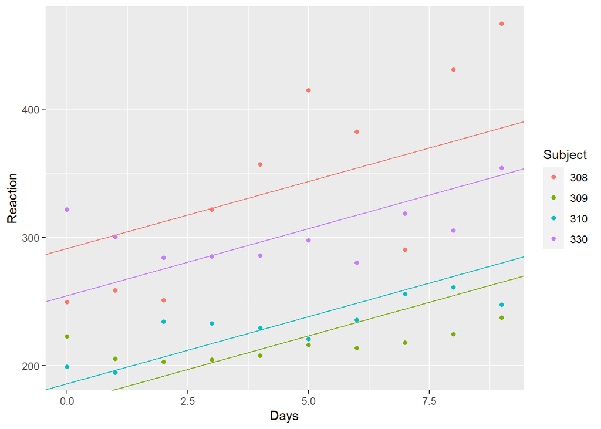

You can also access the individual estimates for each iteration/chain by using the `as_draws()` function on the brms model object. By default this function will return all variables from all chains, excluding estimates from warmup/burn-in draws. You can pull a single variable or list of variables by adding the `variables=c()`, pull values for a specific chain using the `$` operator, and include `inc_warmup = TRUE` to the function call to include warmup draws.

Ex: `as_draws(model1, variables=c('b_Intercept', 'sigma'), inc_warmup=TRUE)$3` will return `b_Intercept` and `sigma` estimates for all 10,000 draws on chain #3.

### Model 2

Our second model has a random intercept term and a random slope, with correlated random effect.
$$y_{ij} =
\beta_0 + \beta_1 t_j + C_{i,0} + C_{i,1}t_j + e_{ij}$$
Reaction time $y_{ij}$ is equal to population intercept $\beta_0$ plus population slope $\beta_1 t$ times the number of days $t_j$, plus subject specific random intercept $C_{i,0}$ plus subject specific random slope $C_{i,1}$ times the number of days $t_j$, plus an error term $e_{ij}$. $C_{i,0}$ and $C_{i,1}$ are both independent of $e_{ij}$.

Additional Assumptions:
$$e_{ij}\sim N(0,\sigma_e)$$
$$\left(\begin{array}{c}
C_{i,0}\\
C_{i,1}\\
\end{array}\right) \sim N_2(0,\Sigma)$$

where
$$\Sigma=\left[\begin{array}{c}
\sigma^2_{C_{i,0}}& \sigma_{(C_{i,0},C_{i,1})}\\
\sigma_{(C_{i,0},C_{i,1})} & \sigma^2_{C_{i,1}}\\
\end{array}\right],$$
$$K=Cov(C_{i,0},
C_{i,1})$$

#### Model 2 - Correlated

We will first build this model allowing correlation between subject specific random effect and number of days. We will fit a base model using *lmer* with correlation denoted by `(Days | Subject)`. We will use the estimates from the base model as priors for a *brm* model.

You can access model estimates, estimated error, 2.5% annd 97.5% credible intervals by using the `posterior_summary()` function on the model object.

```r
posterior_summary(model2c)
```

```
##                                   Estimate Est.Error         Q2.5        Q97.5
## b_Intercept                   239.13134149  7.512832  223.4519557  252.9720327
## b_Days                          7.49038946  1.685312    3.9980605   10.6169029
## sd_Subject__Intercept          27.92996825  6.982659   16.4624515   43.5742991
## sd_Subject__Days                6.86062522  1.535261    4.3370208   10.3619131
## cor_Subject__Intercept__Days    0.23384364  0.280620   -0.3263587    0.7557109
## sigma                          25.87817101  1.566503   23.0622981   29.1759756
## r_Subject[308,Intercept]       14.90065363 14.524967  -13.7261340   43.0788640
## r_Subject[309,Intercept]      -28.98928839 13.052169  -55.1138457   -3.7081107
## r_Subject[310,Intercept]      -27.08822934 12.925609  -53.1626899   -2.4640100
## r_Subject[330,Intercept]       33.86169859 14.726865    6.2210449   64.0647377
## r_Subject[331,Intercept]       32.54119446 14.367577    6.0386985   62.1083630
## r_Subject[332,Intercept]       20.14485007 13.716509   -5.6901362   48.1696038
## r_Subject[333,Intercept]       27.75797505 13.873415    1.7530769   56.4423343
## r_Subject[334,Intercept]        4.66544105 13.242887  -21.5806119   30.8513338
## r_Subject[335,Intercept]        9.51333767 13.849541  -16.3788273   38.0228072
## r_Subject[337,Intercept]       46.47463930 15.326120   16.5202711   77.1202762
## r_Subject[349,Intercept]      -12.80882944 13.501639  -40.1139440   13.0324805
## r_Subject[350,Intercept]       -0.27080968 14.245457  -28.8516764   26.9154071
## r_Subject[351,Intercept]       15.56957456 13.505619   -9.9317937   43.2167160
## r_Subject[352,Intercept]       32.23677655 14.325621    5.4535236   61.4595193
## r_Subject[369,Intercept]       14.83787246 13.610667  -11.2007598   41.9885983
## r_Subject[370,Intercept]      -12.66657238 14.257691  -41.1480755   14.4946311
## r_Subject[371,Intercept]       12.27000145 13.430571  -13.3824913   39.2667199
## r_Subject[372,Intercept]       23.67636966 13.714278   -2.6594276   51.6058688
## r_Subject[308,Days]            12.01912675  2.972533    6.3710398   18.0554472
## r_Subject[309,Days]            -5.75280906  2.632161  -10.9349117   -0.5367681
## r_Subject[310,Days]            -2.64116004  2.628063   -7.6631468    2.6235780
## r_Subject[330,Days]            -1.58424830  2.859687   -7.2478237    3.9814789
## r_Subject[331,Days]             0.14093456  2.849929   -5.4940831    5.6528636
## r_Subject[332,Days]             2.79342888  2.741544   -2.5267255    8.2719024
## r_Subject[333,Days]             2.86967191  2.752468   -2.5226061    8.3060488
## r_Subject[334,Days]             3.97000793  2.692675   -1.2514425    9.3861578
## r_Subject[335,Days]            -7.57336642  2.741939  -13.0220691   -2.3440071
## r_Subject[337,Days]            11.69761814  3.003083    5.9280185   17.7446387
## r_Subject[349,Days]             3.95551254  2.704833   -1.1435388    9.4822042
## r_Subject[350,Days]             9.37280910  2.889919    3.9494806   15.2485161
## r_Subject[351,Days]             0.03491878  2.703472   -5.2773217    5.3541385
## r_Subject[352,Days]             6.60046496  2.821603    1.0817442   12.1757200
## r_Subject[369,Days]             3.84498836  2.733187   -1.4503264    9.2932825
## r_Subject[370,Days]             7.54116832  2.873756    2.1361093   13.3089922
## r_Subject[371,Days]             1.99426986  2.690497   -3.1727017    7.3779662
## r_Subject[372,Days]             4.29147172  2.758246   -1.1499670    9.7357452
## lprior                        -20.68984943  1.720544  -24.7542782  -18.2351032
## lp__                         -904.52087695  6.790761 -918.9711164 -892.3626723
```

Now we can see all estimates for slopes and intercepts in each group and population-wide. The first two lines, `b_Intercept` and `b_Days` represent values for the estimates $\hat\beta_0$ and $\hat\beta_1$, respectively. The next two lines represent the standard deviation of the subject-level intercept, $\hat\sigma_{C,0}$ and slope, $\hat\sigma_{C,1}$

The next line, `cor_Subject__Intercept__Days` is the estimated correlation between subject specific random effect and days - which is 0.23 or a very weak to weak positive association. This suggests that subject specific random intercept is weakly positively correlated with the independent variable days. Sigma represents $\hat\sigma_e$.

The next 36 lines show our model estimates for intercept and days for each individual subject, along with posterior standard deviation (Est.Error), 2.5%, and 97.5% credible intervals.

You can access the random effects of the model using the `$` notation: `summary(model2c)$random`

Data and model estimates can be accessed and plotted by first pulling the subject specific random slopes and intercepts using `coef()` and adding them to a plot with `abline()`.

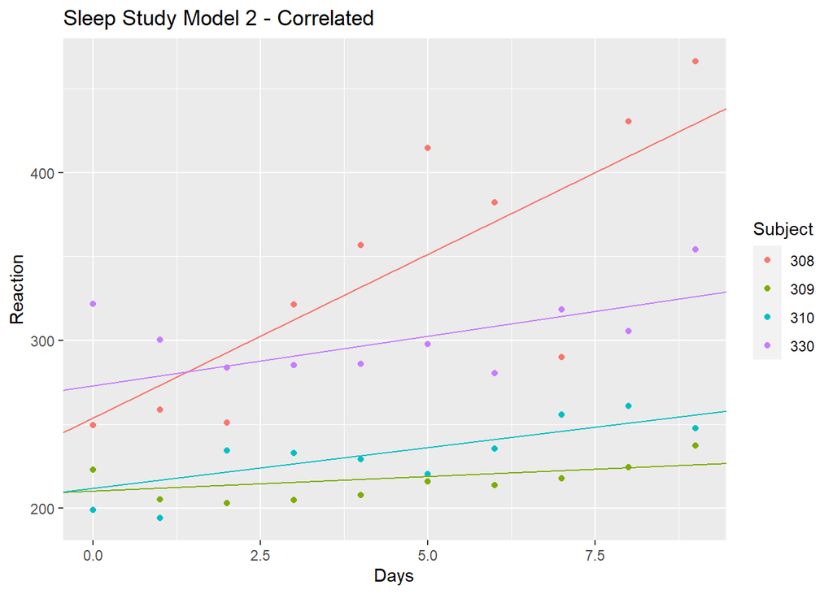

```r
# population level slop estimate
pop_slope <- coef(model2c)[["Subject"]][,,'Days'][,1]
m2c_coefs <- coef(model2c)[["Subject"]][,,'Intercept'][,1]

estimate_df <- data.frame(subject = factor(names(m2c_coefs)),
           slope = pop_slope,
           intercept = m2c_coefs)


# Plotting first 4 subjects
# Function to emulate first 4 default colors from ggplot package
gg_color_hue <- function(n) {
  hues = seq(15, 375, length = n + 1)
  hcl(h = hues, l = 65, c = 100)[1:n]
}

colors = gg_color_hue(4)

sleepstudy %>%
    filter(Subject %in% c(308,309,310,330)) %>% # first 4 subjects
    ggplot(aes(x = Days, y = Reaction, color = Subject)) +
    geom_point() +
    # subject 308
    geom_abline(slope = estimate_df[1,]$slope,
                intercept = estimate_df[1,]$intercept,
                color = colors[1]) +
    # subject 309
    geom_abline(slope = estimate_df[2,]$slope,
                intercept = estimate_df[2,]$intercept,
                color = colors[2]) +
    # subject 310
    geom_abline(slope = estimate_df[3,]$slope,
                intercept = estimate_df[3,]$intercept,
                color = colors[3]) +
    # subject 330
    geom_abline(slope = estimate_df[4,]$slope,
                intercept = estimate_df[4,]$intercept,
                color = colors[4]) +
  ggtitle("Sleep Study Model 2 - Correlated")
```

#### Model 2 - Uncorrelated

If you suspect the random effects are uncorrelated, it is possible to account for htis in the model call. We will build the model with random effects `Days` and `Subject` uncorrelated. This assumes that the subject specific random effect is uncorrelated with days. This is denoted by `(Days || Subject)` in the lmer and brm calls. As before, we will build a base model using `lmer` for prior estimation.

```r
base_model3 <- lmer(Reaction ~ Days + (Days || Subject),data = sleepstudy)

b0 <- summary(base_model3)$coefficients[1,1]
b1 <- summary(base_model3)$coefficients[1,2]
se <- summary(base_model3)$sigma
te <- attr(summary(base_model3)$varcor$Subject, "stddev")[1] # subject specific intercept
be <- attr(summary(base_model3)$varcor$Subject, "stddev")[2]


model2u <- brm(Reaction ~ Days + (Days || Subject),
             data = sleepstudy,
             prior = priors,
             chains = 4,
             iter = 10000,
             thin = 1,
             cores = 4,
             family = gaussian()
             )

# posterior_summary(model2u)
```

```r
summary(model2u)
```

```
##  Family: gaussian
##   Links: mu = identity; sigma = identity
## Formula: Reaction ~ Days + (Days || Subject)
##    Data: sleepstudy (Number of observations: 180)
##   Draws: 4 chains, each with iter = 10000; warmup = 5000; thin = 1;
##          total post-warmup draws = 20000
##
## Group-Level Effects:
## ~Subject (Number of levels: 18)
##               Estimate Est.Error l-95% CI u-95% CI Rhat Bulk_ESS Tail_ESS
## sd(Intercept)    28.25      6.78    16.98    43.57 1.00     9865    13498
## sd(Days)          6.87      1.50     4.43    10.32 1.00     7985    12144
##
## Population-Level Effects:
##           Estimate Est.Error l-95% CI u-95% CI Rhat Bulk_ESS Tail_ESS
## Intercept   240.01      7.87   223.36   254.17 1.00     9505    12610
## Days          7.67      1.79     3.90    10.89 1.00     6445    10823
##
## Family Specific Parameters:
##       Estimate Est.Error l-95% CI u-95% CI Rhat Bulk_ESS Tail_ESS
## sigma    25.72      1.51    22.95    28.86 1.00    24026    15081
##
## Draws were sampled using sampling(NUTS). For each parameter, Bulk_ESS
## and Tail_ESS are effective sample size measures, and Rhat is the potential
## scale reduction factor on split chains (at convergence, Rhat = 1).
```

The output of the summary function is similar to that of the correlated model, with the exception of showing the correlation between the random intercept and days as we are not allowing for correlation with this model. You can use the `posterior_summary()` function to see estimates and credible intervals for each parameter.

#### Model Comparison

There is an additional function `add_criterion()` that allows a model fit criteria to be added to a model object. There is no criteria added to the model build function by default. Instead, a separate call is needed after the model is built.

Criteria choices include:

**loo**: Leave one out cross-validation splits the data into training and testing sets, with the testing set consisting of only one observation. During each iteration, the model is trained and a prediction is made on the left out observation. (Bürkner, 2017)

**kfold**: K-fold cross validation refits the model K times, leaving one/Kth of the original data out. If K is set to the total number of observations in the data, then K-fold is identical to loo. (Bürkner, 2017)

**waic**: Widely Applicable Information Criterion is a generalization of the Akaike Information Criterion (AIC). It differs in that AIC is calculated using a point estimate, usually the maximum likelihood estimate, whereas WAIC is averaged over the posterior distribution. (Vehtari et al, 2013)

**loo_subsample**: An approximation of `loo` using subsampling for efficiency - especially useful for large datasets. (Magnusson, et al. 2019)

**bayes_r2**: Bayesian $r^2$ solves the problem with typical $r^2$ potentially having a numerator that is larger than the denominator. Classical $R^2 = \frac{V_{n=1}^N \hat y_n } {V_{n=1}^Ny_n}$ - or fitted variance over total variance. With strong prior information and weak observed data it is possible for the fitted variance to be larger than total variance. Bayesian $R_s^2=\frac {V_{n=1}^N y_n^{pred s}}{V_{n=1}^N y_n^{pred s} + var_{res}^s}$, or explained variance over explained variance plus residual variance. For a linear model, $y_n^{pred s}$ is simply the linear predictor ($X_n\beta$). For a generalized linear model, $y_n^{pred s}$ is the transformed linear predictor, with transformation dependent on which family is used. (Vehtari, et al. 2018)

**marglik**: This criterion uses log marginal likelihood for model comparison. This is also referred to as the model evidence and uses the Bayes factor to determine which model is best. This is computationally expensive due to the additional posterior draws needed to compute the likelihood. To use this criterion, you must set `save_pars = save_pars(all=TRUE)` in the original brm function call to save all parameters. The brms package implements bridge sampling to calculate the marginal likelihood. (Bürkner, 2017)

Here, we will create a function that accepts a model object as an argument and will return the model with several criteria added.

```r
# Function to add comparison criteria to a model
update_model <- function(model){
  model_crit <- add_criterion(model, c("waic", "loo", "bayes_R2"))
  model_crit$comparison <- data.frame(
      model_name = deparse(substitute(model)),
      waic = model_crit$criteria$waic$waic,
      loo = model_crit$criteria$loo$loo,
      bayes_R2 = mean(model_crit$criteria$bayes_R2)
    )
  return(model_crit)
}

# Add critera to each model
model1 <- update_model(model1)
model2c <- update_model(model2c)
model2u <- update_model(model2u)

# Build data frame with model criteria
df <- rbind(model1$comparison,
        model2c$comparison,
        model2u$comparison)

library(knitr)
knitr::kable(df)
```

| model_name | waic | loo | bayes_R2 |
| --- | --- | --- | --- |
| model1 | 1769.527 | 1770.067 | 0.7008408 |
| model2c | 1720.285 | 1725.290 | 0.7923769 |
| model2u | 1718.855 | 1722.523 | 0.7948605 |

For both waic and loo we are looking for the model with the lowest number. In each case, waic is lower than loo and model 2 - uncorrelated performs the best.

For bayes r2 we are looking for the highest number which would represent the most variance explained by the model. This criterion also chooses model 2 - uncorrelated as the best performing model.

Ultimately, you should check and compare several to make an informed decision on which model to proceed with in any given problem.

## Nonlinear Mixed Models

We will utilize the `brms` package to approach a nonlinear problem with a Bayesian mixed model.

### Introduction to the dataset

The `lme4` package offers another dataset, “Contagious Bovine Pleuropneumonia” (CBPP) that is accessible using `data(cbpp)`. This dataset describes the serological incidence of CBPP in zebu cattle during a survey implemented in 15 commercial herds in Ethiopia. The data contains 4 colums: 1. herd - a factor identifying the herd 2. incidence - the number of new serological cases for a given herd and time period 3. size - the number describing the size of the herd at the beginning of a given time period 4. period - a factors with levels 1 to 4.

```r
head(cbpp)
```

```
##   herd incidence size period
## 1    1         2   14      1
## 2    1         3   12      2
## 3    1         4    9      3
## 4    1         0    5      4
## 5    2         3   22      1
## 6    2         1   18      2
```

First we’ll plot the data points, colored by herd:

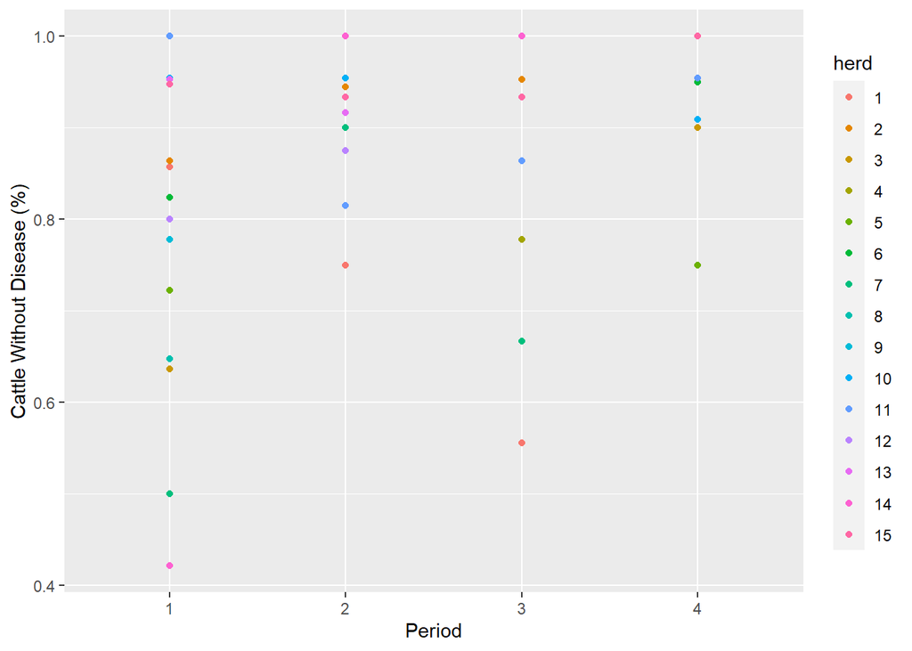

It is a little difficult to see which points belong to which herd. We can add a line to make it a little more clear:

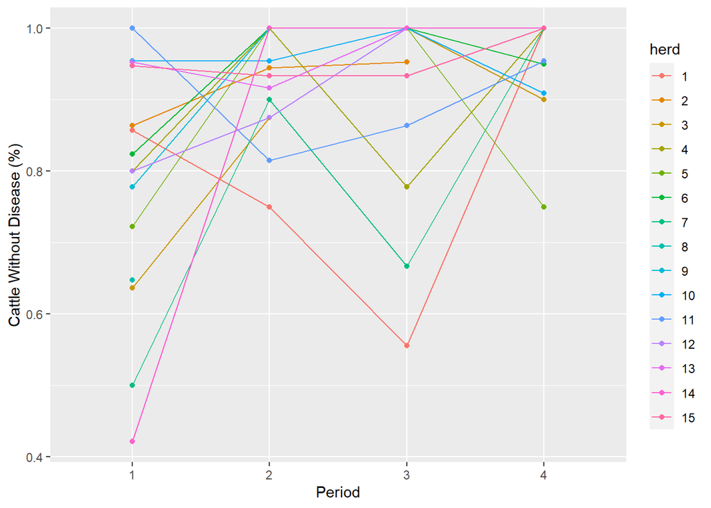

```r
cbpp %>%
  ggplot(aes(x = period, y = (size-incidence)/size, group=herd)) +
  geom_point(aes(col=herd)) +
  geom_line(aes(col=herd)) +
  ylab("Cattle Without Disease (%)") +
  xlab("Period")
```

### Model

We will fit a generalized linear mixed model with family “binomial”. This model will have a random herd specific intercept and random period specific intercept. As before, we will build a model using the `lmer` package first to obtain priors.

$$ln(\frac{Pr(healthy_i=1)}{Pr(healthy_i=0)})=\beta_0
+ \beta_h + \beta_p$$
where
* Term $\beta_0$ is the population intercept
* Term $\beta_h$ is is the random herd-level intercept for herd $h$
* Term $\beta_p$ is the random period-level intercept for period $p$

The herd level random effects are assumed to come from an iid normal distribution with mean 0 and some shared, herd-level variance, $\beta_h \sim N(0,\sigma^2_h)$ , $h \in {1,...,15}$. Period-level random intercepts are assumed iid normal, mean 0 and shared period-level variance, $\beta_p \sim N(0,\sigma^2_p)$, $p\in {1,2,3,4}$.

### Priors

There is a useful function in the `brms` package that gives information on all parameters that may have priors assigned, including the default priors that the package will use if unspecified.

Calling the `get_prior()` function with the formula, family, and data specified shows this information:

```r
# Get priors for our model
get_prior(cbind(incidence, size-incidence) ~ (1 | period) + (1 | herd),
      family = binomial(link="logit"),
      data = cbpp)
```

```
##                 prior     class      coef  group resp dpar nlpar lb ub
##  student_t(3, 0, 2.5) Intercept
##  student_t(3, 0, 2.5)        sd                                   0
##  student_t(3, 0, 2.5)        sd             herd                  0
##  student_t(3, 0, 2.5)        sd Intercept   herd                  0
##  student_t(3, 0, 2.5)        sd           period                  0
##  student_t(3, 0, 2.5)        sd Intercept period                  0
##        source
##       default
##       default
##  (vectorized)
##  (vectorized)
##  (vectorized)
##  (vectorized)
```

### Fitting a Model

As before, we will build a model first using the `lmer` package to obtain priors for a `brm` model.

```r
nlin_base_model <- glmer(cbind(incidence, size-incidence) ~ (1 | period) + (1 | herd),
      family = binomial(link="logit"),
      data = cbpp)

s <- summary(nlin_base_model)

coef(nlin_base_model)
```

There is a slight change in notation in the `brm` call here since we are using a generalized binomial model. The left side of the model reads `size-incidence | trials(size)`, which notes the number of successes on the left (herd size - incidence) and the size of each herd inside of `trials()` on the right.

```r
priors <- c(prior(normal(-2.3, 10), class = Intercept), # pop slope
            prior(normal(0, 1), class = sd), # residual error
            prior(normal(0, 0.71), class = sd, group = herd, coef = Intercept), # herd-level intercept sd
            prior(normal(0, 0.54), class = sd, group = period, coef = Intercept)) # period-level intercept sd

nonlin_bayes <- brm(size-incidence | trials(size) ~ (1 | period) + (1 | herd),
      family = binomial(link="logit"),
      data = cbpp,
      prior = priors,
      chains = 4,
      iter = 10000,
      thin = 1,
      cores = 4
    )
```

Model summary:

```
##  Family: binomial
##   Links: mu = logit
## Formula: size - incidence | trials(size) ~ (1 | period) + (1 | herd)
##    Data: cbpp (Number of observations: 56)
##   Draws: 4 chains, each with iter = 10000; warmup = 5000; thin = 1;
##          total post-warmup draws = 20000
##
## Group-Level Effects:
## ~herd (Number of levels: 15)
##               Estimate Est.Error l-95% CI u-95% CI Rhat Bulk_ESS Tail_ESS
## sd(Intercept)     0.71      0.19     0.39     1.14 1.00     7801    11813
##
## ~period (Number of levels: 4)
##               Estimate Est.Error l-95% CI u-95% CI Rhat Bulk_ESS Tail_ESS
## sd(Intercept)     0.63      0.23     0.28     1.18 1.00    10368    13049
##
## Population-Level Effects:
##           Estimate Est.Error l-95% CI u-95% CI Rhat Bulk_ESS Tail_ESS
## Intercept     2.28      0.41     1.50     3.13 1.00     6907     8583
##
## Draws were sampled using sampling(NUTS). For each parameter, Bulk_ESS
## and Tail_ESS are effective sample size measures, and Rhat is the potential
## scale reduction factor on split chains (at convergence, Rhat = 1).
```

Posterior summary:

```
##                            Estimate Est.Error          Q2.5         Q97.5
## b_Intercept              2.28391977 0.4102305    1.49770590    3.13306134
## sd_herd__Intercept       0.71329789 0.1913444    0.38675116    1.13977597
## sd_period__Intercept     0.63179653 0.2339795    0.27989634    1.17898059
## r_herd[1,Intercept]     -0.58160124 0.4034866   -1.38894637    0.19843618
## r_herd[2,Intercept]      0.33066748 0.4133710   -0.43241441    1.19504383
## r_herd[3,Intercept]     -0.37634102 0.3603822   -1.08467205    0.31796448
## r_herd[4,Intercept]      0.00037756 0.4538506   -0.86586405    0.92786660
## r_herd[5,Intercept]      0.22400886 0.3988354   -0.53521359    1.04192531
## r_herd[6,Intercept]      0.47192133 0.4330845   -0.31802427    1.38883096
## r_herd[7,Intercept]     -0.89366550 0.3938090   -1.68390880   -0.13808174
## r_herd[8,Intercept]     -0.65856701 0.3971243   -1.47277528    0.08239591
## r_herd[9,Intercept]      0.30326284 0.5029703   -0.62885315    1.37209816
## r_herd[10,Intercept]     0.61021201 0.4330820   -0.17898873    1.52342871
## r_herd[11,Intercept]     0.12550992 0.3633786   -0.57817806    0.86266362
## r_herd[12,Intercept]     0.10986326 0.4802435   -0.78806114    1.09580053
## r_herd[13,Intercept]     0.77484924 0.4540598   -0.03840576    1.73979590
## r_herd[14,Intercept]    -1.01512189 0.4361719   -1.89886246   -0.19418136
## r_herd[15,Intercept]     0.60143575 0.4549382   -0.22898320    1.55369509
## r_period[1,Intercept]   -0.80325411 0.3856010   -1.62721941   -0.09042191
## r_period[2,Intercept]    0.09600404 0.3927933   -0.69502946    0.87141321
## r_period[3,Intercept]    0.20426707 0.3993152   -0.59189125    1.01414440
## r_period[4,Intercept]    0.50308804 0.4298906   -0.29015981    1.42499377
## lprior                  -4.13961190 0.6710109   -5.85077710   -3.29817709
## lp__                  -117.57528636 4.1659897 -126.66710930 -110.46273919
```

### Prediction

There are two ways to make predictions from a `brm` model. The first way is to use the generic `predict()` function that is built in. This function which will return an estimate using the fitted parameters from the model including the estimated error and quantiles.

If the interest is in predicting the number of healthy cattle from herd #2 in period 4 with a total size of 15, we can use the following code:

```r
predict(nonlin_bayes, newdata = data.frame(herd = 2,
                                           period =4,
                                           size =15))
```

```
##      Estimate Est.Error Q2.5 Q97.5
## [1,]  14.2806 0.8978329   12    15
```

The second way is to use the `posterior_predict()` function that is built in to the `brms` package. This will return an S x N array of values where S is the total number of posterior draws from our model (total number of chains x number of post burn-in draws = 4 x 5,000 in our example) and N is the number of observations being predicted.

The output represent the predicted number of healthy (non-diseased) cattle.

```r
preds <- posterior_predict(nonlin_bayes, newdata = data.frame(herd = 2,
                                           period =4,
                                           size =15))

head(preds)
```

```
##      [,1]
## [1,]   14
## [2,]   15
## [3,]   14
## [4,]   15
## [5,]   15
## [6,]   14
```

You can also return the predictive probability by dividing by the “size” input. Predictive probability:
$$pr(healthy)=\frac{exp(\hat\beta_0+\hat\beta_h+\hat\beta_p)}
{1+exp(\hat\beta_0+\hat\beta_h+\hat\beta_p)}$$
A simple way to show a histogram of the predictive probabilities is to use the `hist()` function:

```r
(preds / 15) %>% head()
```

```
##           [,1]
## [1,] 0.9333333
## [2,] 1.0000000
## [3,] 0.9333333
## [4,] 1.0000000
## [5,] 1.0000000
## [6,] 0.9333333
```

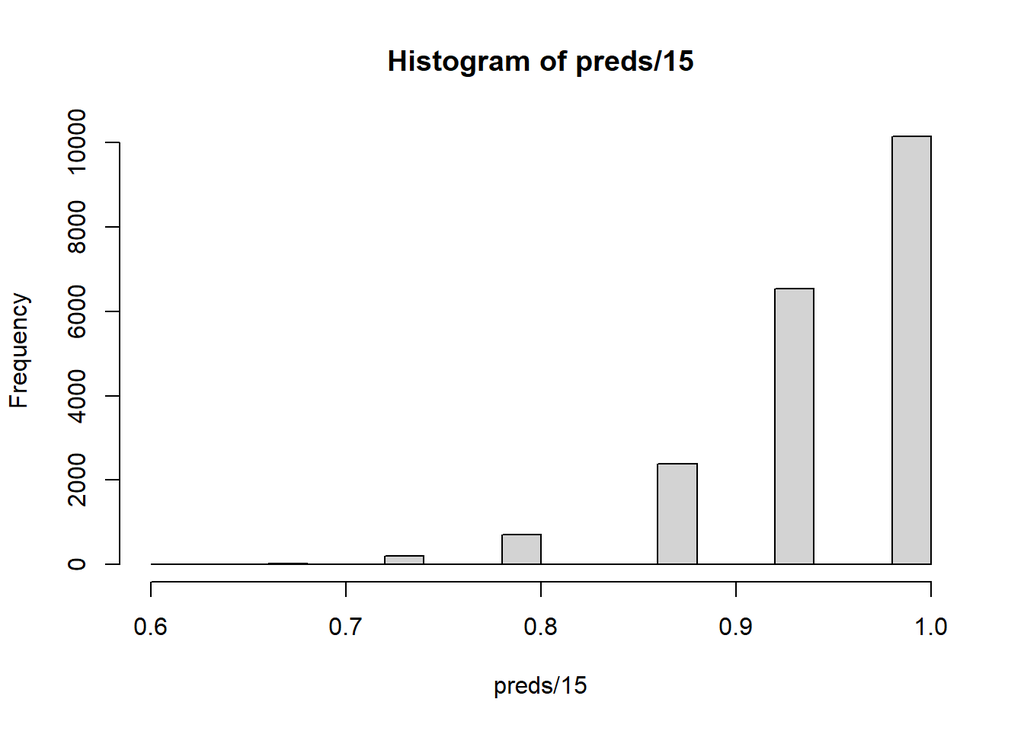

```r
hist(preds/15)
```

In Bayesian context, we have the benefit of a distribution of estimates rather than a single point estimate. To view model estimates for each parameter, you can use the `as_draws()` function as we did earlier. The code below outputs $\hat\beta_0$ estimates from all post burn-in draws from chain 1:

```r
as_draws(nonlin_bayes)$`1`$b_Intercept
```

```r
chain1 <- as_draws(nonlin_bayes)$`1`
chain2 <- as_draws(nonlin_bayes)$`2`
chain3 <- as_draws(nonlin_bayes)$`3`
chain4 <- as_draws(nonlin_bayes)$`4`

beta_hat0 <- c(chain1$b_Intercept,
            chain2$b_Intercept,
            chain3$b_Intercept,
            chain4$b_Intercept)

beta_hath2 <- c(chain1$`r_herd[2,Intercept]`,
             chain2$`r_herd[2,Intercept]`,
             chain3$`r_herd[2,Intercept]`,
             chain4$`r_herd[2,Intercept]`)

beta_hatp4 <- c(chain1$`r_period[4,Intercept]`,
             chain2$`r_period[4,Intercept]`,
             chain3$`r_period[4,Intercept]`,
             chain4$`r_period[4,Intercept]`)

beta_hat_df<- data.frame('beta_hat_0' = beta_hat0,
           'beta_hat_h2' = beta_hath2,
           'beta_hat_p4' = beta_hatp4)

kable(head(beta_hat_df))
```

| beta_hat_0 | beta_hat_h2 | beta_hat_p4 |
| --- | --- | --- |
| 2.374902 | -0.0404640 | 0.9747979 |
| 3.016622 | -0.1782411 | 0.4003532 |
| 2.815676 | 0.2750508 | 0.0433910 |
| 2.579490 | -0.2674268 | 0.3524396 |
| 2.512940 | 0.4883709 | 0.0381509 |
| 2.247497 | 0.9576911 | 0.0754421 |

# References

https://cran.microsoft.com/snapshot/2021-10-10/web/packages/lme4/vignettes/lmer.pdf  
https://www.lcampanelli.org/mixed-effects-modeling-lme4/  
https://www.rensvandeschoot.com/tutorials/lme4/  
https://vitalflux.com/fixed-vs-random-vs-mixed-effects-models-examples/  
https://www.rdocumentation.org/packages/lme4/versions/1.1-29/topics/lmer  
https://www.ncbi.nlm.nih.gov/pmc/articles/PMC5970551/

Bürkner, P.-C. (2017). brms: An R Package for Bayesian Multilevel Models Using Stan. Journal of Statistical Software, 80(1), 1–28. https://doi.org/10.18637/jss.v080.i01

Vehtari A., Gelman A., Goodrich B., Gabry J. (2019) Bayesian R2 and LOO-R2 (https://avehtari.github.io/bayes_R2/bayes_R2.html)

Vehtari A., Gelman A., Goodrich B., Gabry J. (2018) R-squared for Bayesian regression models (http://www.stat.columbia.edu/~gelman/research/unpublished/bayes_R2.pdf)

Vehtari et al (2013). Understanding predictive information criteria for Bayesian models. http://www.stat.columbia.edu/~gelman/research/published/waic_understand3.pdf

Vehtari A., Gelman A., Simpson D., Carpenter B., and Bürkner P. (2021). Rank-normalization, folding, and localization: An improved R-hat for assessing convergence of MCMC (with discussion). Bayesian Data Analysis. (https://projecteuclid.org/journals/bayesian-analysis/advance-publication/Rank-Normalization-Folding-and-Localization--An-Improved-R%CB%86-for/10.1214/20-BA1221.full)

Magnusson M., Vehtari A., Jonasson J., Anderson M. - Bayesian leave-one-out cross-validation for large data (2019) (http://proceedings.mlr.press/v97/magnusson19a/magnusson19a.pdf)

Gregory Belenky, Nancy J. Wesensten, David R. Thorne, Maria L. Thomas, Helen C. Sing, Daniel P. Redmond, Michael B. Russo and Thomas J. Balkin (2003). [[Sleepstudy data]]